# [Numpy](https://numpy.org/doc/stable/index.html)

```python
import numpy as np
```

Tipos de numpy

```python
np.bool_, np.byte, np.ubyte, np.short, np.ushort, np.intc, np.uintc, np.int_, np.uint, np.longlong, np.ulonglong, np.half, np.float16, np.single, np.double, np.longdouble, np.csingle, np.cdouble, np.clongdouble
```

```
(numpy.bool_,
 numpy.int8,
 numpy.uint8,
 numpy.int16,
 numpy.uint16,
 numpy.intc,
 numpy.uintc,
 numpy.int32,
 numpy.uint32,
 numpy.int64,
 numpy.uint64,
 numpy.float16,
 numpy.float16,
 numpy.float32,
 numpy.float64,
 numpy.longdouble,
 numpy.complex64,
 numpy.complex128,
 numpy.clongdouble)
```

## [Arrays](https://numpy.org/doc/stable/reference/arrays.html)

Los arrays son el tipo de datos más importante que provee NumPy. En su versión más básica representan vectores pero pueden tener más dimensiones y representar matrices y tensores en general.

El tipo se llama ndarray pero también se lo conoce en la librería simplemente como array.

En su versión más simple podemos pensar que no es más que una lista de python pero:

- A diferencia de las listas en python, solo pueden tener un tipo de datos adentro.
- Existen un montón de operaciones matemáticas definidas y optimizadas para trabajar con este tipo de datos.

Al ser una clase de python, además de métodos tiene atributos. Veamos algunos de ellos

```python
an_array = np.arange(20)
an_array
```

```
array([ 0,  1,  2,  3,  4,  5,  6,  7,  8,  9, 10, 11, 12, 13, 14, 15, 16,
       17, 18, 19])
```

```python
an_array.shape
```

```
(20,)
```

```python
an_array.ndim
```

```
1
```

```python
an_array.size
```

```
20
```

```python
an_array.dtype
```

```
dtype('int32')
```

### [Armando arrays](https://numpy.org/doc/stable/user/basics.creation.html)

Por un lado, tenemos el constructor de la clase que admite como parámetro listas de valores. Por otro lado, existen diversas funciones que crean arrays. Veamos algunas.

```python
np.array([1,2,3,4])
```

```
array([1, 2, 3, 4])
```

```python
np.arange(10,30,2)
```

```
array([10, 12, 14, 16, 18, 20, 22, 24, 26, 28])
```

```python
np.linspace(0.1,0.5,4)
```

```
array([0.1       , 0.23333333, 0.36666667, 0.5       ])
```

```python
np.logspace(1,10,10)
```

```
array([1.e+01, 1.e+02, 1.e+03, 1.e+04, 1.e+05, 1.e+06, 1.e+07, 1.e+08,
       1.e+09, 1.e+10])
```

```python
np.zeros((3,2))
```

```
array([[0., 0.],
       [0., 0.],
       [0., 0.]])
```

```python
np.ones((2,3))
```

```
array([[1., 1., 1.],
       [1., 1., 1.]])
```

```python
np.random.rand(3,2) # random entre 0 y 1
```

```
array([[0.76379911, 0.50588607],
       [0.4860541 , 0.06006322],
       [0.51547972, 0.87075031]])
```

```python
np.random.randint(1,10,(3,2)) # enteros random entre [1 y 10)
```

```
array([[6, 6],
       [2, 5],
       [3, 5]])
```

```python
np.random.standard_normal((8,2))
```

```
array([[ 0.22589801,  1.14360121],
       [ 1.63693665,  0.06760067],
       [ 0.97625415,  1.10216175],
       [-1.0928834 ,  0.40026374],
       [-1.59486158, -0.06845085],
       [ 0.64153634,  1.12754117],
       [-0.91460122,  0.6652602 ],
       [-0.54398611,  0.5702071 ]])
```

Propiedades de un arreglo

```python
an_array = np.ones((2,3))
print('dimensiones: ', an_array.shape)
print('cantidad de dimensiones: ', an_array.ndim)
print('cantidad de elementos: ', an_array.size)
print('tipo: ', an_array.dtype)
```

```
dimensiones:  (2, 3)
cantidad de dimensiones:  2
cantidad de elementos:  6
tipo:  float64
```

Se puede cambiar el tipo de un array

```python
np.arange(0,10,0.5)
```

```
array([0. , 0.5, 1. , 1.5, 2. , 2.5, 3. , 3.5, 4. , 4.5, 5. , 5.5, 6. ,
       6.5, 7. , 7.5, 8. , 8.5, 9. , 9.5])
```

```python
np.arange(0,10,0.5).astype(np.int32)
```

```
array([0, 0, 1, 1, 2, 2, 3, 3, 4, 4, 5, 5, 6, 6, 7, 7, 8, 8, 9, 9])
```

## Matrices

Las matrices no son más que array con 2 dimensiones. Si bien existe un tipo específico para matrices en numpy cayó en desuso (y obsolescencia).

```python
a_matrix = np.array([[ 0,  1,  2,  3],
                    [ 4,  5,  6,  7],
                    [ 8,  9, 10, 11],
                    [12, 13, 14, 15]])
a_matrix
```

```
array([[ 0,  1,  2,  3],
       [ 4,  5,  6,  7],
       [ 8,  9, 10, 11],
       [12, 13, 14, 15]])
```

```python
print(a_matrix.shape, a_matrix.ndim, a_matrix.size, a_matrix.dtype)
```

```
(4, 4) 2 16 int32
```

### Matrices especiales

```python
np.eye(3) # Identidad de 3x3
```

```
array([[1., 0., 0.],
       [0., 1., 0.],
       [0., 0., 1.]])
```

```python
np.diag([77,90]) # Matriz diagonal
```

```
array([[77,  0],
       [ 0, 90]])
```

```python
np.diag(np.ones(3),1) # Superdiagonal 1
```

```
array([[0., 1., 0., 0.],
       [0., 0., 1., 0.],
       [0., 0., 0., 1.],
       [0., 0., 0., 0.]])
```

```python
np.vander(np.arange(4),increasing=True) # Matriz de Vandermonde (veremos al final de la materia qué significa)
```

```
array([[ 1,  0,  0,  0],
       [ 1,  1,  1,  1],
       [ 1,  2,  4,  8],
       [ 1,  3,  9, 27]])
```

## Cambio de dimensiones

Algunos métodos que modifican las dimensiones:

- reshape: Devuelve un nuevo array con las dimensiones indicadas como

parámetro. Si alguno de los parámetros es igual a -1, se calculan las dimensiones para que sea factible el cambio.

- resize: el mismo efecto que “reshape” pero modifica el array en vez de devolver

uno nuevo.

- T: sirve para transponer una matriz.
- ravel, flattened: “aplana” el array devolviendo todo en una sola dimensión.

```python
a_matrix
```

```
array([[ 0,  1,  2,  3],
       [ 4,  5,  6,  7],
       [ 8,  9, 10, 11],
       [12, 13, 14, 15]])
```

```python
a_matrix.reshape(1,16)
```

```
array([[ 0,  1,  2,  3,  4,  5,  6,  7,  8,  9, 10, 11, 12, 13, 14, 15]])
```

```python
a_matrix.T
```

```
array([[ 0,  4,  8, 12],
       [ 1,  5,  9, 13],
       [ 2,  6, 10, 14],
       [ 3,  7, 11, 15]])
```

```python
a_matrix.ravel()
```

```
array([ 0,  1,  2,  3,  4,  5,  6,  7,  8,  9, 10, 11, 12, 13, 14, 15])
```

```python
a_matrix.resize(1,16)
a_matrix
```

```
array([[ 0,  1,  2,  3,  4,  5,  6,  7,  8,  9, 10, 11, 12, 13, 14, 15]])
```

## Operaciones con arrays

Existen muchísimas operaciones definidas para arrays.

### Operadores básicos

Los operadores básicos de sumas, restas, potencias, etc se encuentran sobrecargados.

```python
v = np.arange(1,7)
w = np.ones(6)
v, w
```

```
(array([1, 2, 3, 4, 5, 6]), array([1., 1., 1., 1., 1., 1.]))
```

```python
v + w
```

```
array([2., 3., 4., 5., 6., 7.])
```

```python
v > w
```

```
array([False,  True,  True,  True,  True,  True])
```

```python
v - w
```

```
array([0., 1., 2., 3., 4., 5.])
```

```python
v ** 2
```

```
array([ 1,  4,  9, 16, 25, 36])
```

```python
np.sqrt(v)
```

```
array([1.        , 1.41421356, 1.73205081, 2.        , 2.23606798,
       2.44948974])
```

```python
print(np.sin(v), "\n", np.cos(v), "\n", np.floor(np.cos(v)), "\n", np.round(np.cos(v)))
```

```
[ 0.84147098  0.90929743  0.14112001 -0.7568025  -0.95892427 -0.2794155 ]
 [ 0.54030231 -0.41614684 -0.9899925  -0.65364362  0.28366219  0.96017029]
 [ 0. -1. -1. -1.  0.  0.]
 [ 1. -0. -1. -1.  0.  1.]
```

### Operaciones entre vectores

```python
np.dot(v,w) #Producto iterno (o escalar)
```

```
21.0
```

```python
np.outer(v,w) #Producto externo
```

```
array([[1., 1., 1., 1., 1., 1.],
       [2., 2., 2., 2., 2., 2.],
       [3., 3., 3., 3., 3., 3.],
       [4., 4., 4., 4., 4., 4.],
       [5., 5., 5., 5., 5., 5.],
       [6., 6., 6., 6., 6., 6.]])
```

### Multiplicación de matrices

Existe la multiplicación clásica entre matrices (con el símbolo @) o el producto elemento a elemento (producto Hadamard)

```python
M1 = np.arange(1,10).reshape(3,3)
M2 = np.ones((3,3))
M1, M2
```

```
(array([[1, 2, 3],
        [4, 5, 6],
        [7, 8, 9]]),
 array([[1., 1., 1.],
        [1., 1., 1.],
        [1., 1., 1.]]))
```

```python
M1 * M2 #Producto Hadamard o elemento a elemento
```

```
array([[1., 2., 3.],
       [4., 5., 6.],
       [7., 8., 9.]])
```

```python
np.matmul(M1,M2) #Producto interno de matrices
```

```
array([[ 6.,  6.,  6.],
       [15., 15., 15.],
       [24., 24., 24.]])
```

```python
M1 @ M2 #Producto interno de matrices
```

```
array([[ 6.,  6.,  6.],
       [15., 15., 15.],
       [24., 24., 24.]])
```

**EJERCICIO**: Multiplicar $M_{1}v$ siendo $v = (1,1,1)$ como columna

```python
v = np.ones(3).reshape(3,1)
M1 @ v
```

```
array([[ 6.],
       [15.],
       [24.]])
```

## [Indexación de arreglos](https://numpy.org/doc/stable/user/basics.indexing.html)

Los arrays en NumPy se pueden acceder a posiciones particulares o mediante 'slicing' de maneras parecidas a las listas nativas. Observar los siguientes comandos e interpretar.

```python
an_array = np.arange(0,40,2)
an_array
```

```
array([ 0,  2,  4,  6,  8, 10, 12, 14, 16, 18, 20, 22, 24, 26, 28, 30, 32,
       34, 36, 38])
```

```python
an_array[6]
```

```
12
```

```python
start = 2
end = 18
step = 2
#indice 2 a 18 de a 2
an_array[start:end:step]
```

```
array([ 4,  8, 12, 16, 20, 24, 28, 32])
```

```python
# Son equivalentes
#an_array[0:end:]
#an_array[:end:]
an_array[:end]
```

```
array([ 0,  2,  4,  6,  8, 10, 12, 14, 16, 18, 20, 22, 24, 26, 28, 30, 32,
       34])
```

```python
an_array[:-1]
```

```
array([ 0,  2,  4,  6,  8, 10, 12, 14, 16, 18, 20, 22, 24, 26, 28, 30, 32,
       34, 36])
```

```python
an_array[::]
```

```
array([ 0,  2,  4,  6,  8, 10, 12, 14, 16, 18, 20, 22, 24, 26, 28, 30, 32,
       34, 36, 38])
```

```python
an_array[::-1]
```

```
array([38, 36, 34, 32, 30, 28, 26, 24, 22, 20, 18, 16, 14, 12, 10,  8,  6,
        4,  2,  0])
```

```python
for element in an_array[:5]:
    print(element)
```

```
0
2
4
6
8
```

```python
a_matrix = np.arange(16).reshape((4,4))
a_matrix
```

```
array([[ 0,  1,  2,  3],
       [ 4,  5,  6,  7],
       [ 8,  9, 10, 11],
       [12, 13, 14, 15]])
```

```python
a_matrix[:,2]
```

```
array([ 2,  6, 10, 14])
```

```python
a_matrix[:,1:3]
```

```
array([[ 1,  2],
       [ 5,  6],
       [ 9, 10],
       [13, 14]])
```

```python
a_matrix[-1,:]
```

```
array([12, 13, 14, 15])
```

```python
for row in a_matrix:
    print(row)
```

```
[0 1 2 3]
[4 5 6 7]
[ 8  9 10 11]
[12 13 14 15]
```

```python
a_matrix[1:3,2:4]
```

```
array([[ 6,  7],
       [10, 11]])
```

## Máscaras

Es posible seleccionar elementos de un arreglo utilizando como índice otro arreglo de booleanos. Esto es mucho más eficiente que realizar un ciclo que recorra todo el arreglo y ejecute una condición en cada posición.

```python
import time

an_array = np.arange(4)
mask = np.array([False,True,True,False])
an_array[mask]
```

```
array([1, 2])
```

Las operaciones con máscaras son más rápidas que operar elemento a elemento con condiciones

```python
an_array = np.arange(100)
an_array
```

```
array([ 0,  1,  2,  3,  4,  5,  6,  7,  8,  9, 10, 11, 12, 13, 14, 15, 16,
       17, 18, 19, 20, 21, 22, 23, 24, 25, 26, 27, 28, 29, 30, 31, 32, 33,
       34, 35, 36, 37, 38, 39, 40, 41, 42, 43, 44, 45, 46, 47, 48, 49, 50,
       51, 52, 53, 54, 55, 56, 57, 58, 59, 60, 61, 62, 63, 64, 65, 66, 67,
       68, 69, 70, 71, 72, 73, 74, 75, 76, 77, 78, 79, 80, 81, 82, 83, 84,
       85, 86, 87, 88, 89, 90, 91, 92, 93, 94, 95, 96, 97, 98, 99])
```

```python
np.array([x for x in an_array if x>50])
```

```
array([51, 52, 53, 54, 55, 56, 57, 58, 59, 60, 61, 62, 63, 64, 65, 66, 67,
       68, 69, 70, 71, 72, 73, 74, 75, 76, 77, 78, 79, 80, 81, 82, 83, 84,
       85, 86, 87, 88, 89, 90, 91, 92, 93, 94, 95, 96, 97, 98, 99])
```

```python
an_array[an_array>50]
```

```
array([51, 52, 53, 54, 55, 56, 57, 58, 59, 60, 61, 62, 63, 64, 65, 66, 67,
       68, 69, 70, 71, 72, 73, 74, 75, 76, 77, 78, 79, 80, 81, 82, 83, 84,
       85, 86, 87, 88, 89, 90, 91, 92, 93, 94, 95, 96, 97, 98, 99])
```

```python
%timeit np.array([x for x in an_array if x>50])
```

```
The slowest run took 7.49 times longer than the fastest. This could mean that an intermediate result is being cached.
69.4 µs ± 54 µs per loop (mean ± std. dev. of 7 runs, 10,000 loops each)
```

```python
%timeit an_array[an_array>50]
```

```
12.7 µs ± 6.3 µs per loop (mean ± std. dev. of 7 runs, 100,000 loops each)
```

## Tipos de asignación

### Referencia

```python
an_array = np.arange(10)
an_array
```

```
array([0, 1, 2, 3, 4, 5, 6, 7, 8, 9])
```

```python
another_array = an_array
```

```python
another_array[3] = 8
an_array
```

```
array([0, 1, 2, 8, 4, 5, 6, 7, 8, 9])
```

### [Vista](https://numpy.org/doc/stable/user/basics.copies.html)

```python
an_array = np.arange(10)
an_array
```

```
array([0, 1, 2, 3, 4, 5, 6, 7, 8, 9])
```

```python
another_array = an_array.view()
```

```python
another_array = another_array.reshape((5,2))
another_array
```

```
array([[0, 1],
       [2, 3],
       [4, 5],
       [6, 7],
       [8, 9]])
```

```python
an_array[3] = 8
```

```python
another_array
```

```
array([[0, 1],
       [2, 8],
       [4, 5],
       [6, 7],
       [8, 9]])
```

### [Copia](https://numpy.org/doc/stable/user/basics.copies.html)

```python
another_array = np.arange(10)
```

```python
an_array = another_array.copy()
```

```python
an_array[3] = 8
```

```python
an_array, another_array
```

```
(array([0, 1, 2, 8, 4, 5, 6, 7, 8, 9]), array([0, 1, 2, 3, 4, 5, 6, 7, 8, 9]))
```

## Operaciones matemáticas

```python
np.sum(np.arange(1000)) # suma los elementos de un arreglo
```

```
499500
```

```python
arr = np.arange(16).reshape(4,4,)
np.sum(arr,0) #  de un arreglo 2d, suma solo un eje, el 0, el primero
```

```
array([24, 28, 32, 36])
```

```python
np.diff(np.arange(10)) # resta elementos consecutivos
```

```
array([1, 1, 1, 1, 1, 1, 1, 1, 1])
```

```python
np.cumsum(np.arange(10)) # suma acumulada
```

```
array([ 0,  1,  3,  6, 10, 15, 21, 28, 36, 45])
```

## Álgebra Lineal

Numpy utiliza BLAS y LAPACK para las operaciones de álgebra lineal

https://numpy.org/doc/stable/reference/routines.linalg.html#module-numpy.linalg

Descomposiciones, autovalores, normas, determinante, rango, sistemas de ecuaciones, inversa, ...

```python
import numpy.linalg as lng
```

```python
A = np.random.randint(1,10,(3,3))
A
```

```
array([[2, 8, 5],
       [2, 2, 9],
       [5, 7, 6]])
```

```python
lng.inv(A)  # Inversa
```

```
array([[-0.28021978, -0.07142857,  0.34065934],
       [ 0.18131868, -0.07142857, -0.04395604],
       [ 0.02197802,  0.14285714, -0.06593407]])
```

```python
lng.det(A)  # Determinante
```

```
181.99999999999997
```

## Resolver sistemas de ecuaciones

```python
A = np.random.randint(-9,10,(4,4))
x = np.random.randint(-9,10,(4,1))
b = A@x
A, x, b
```

```
(array([[-2,  4,  6,  0],
        [ 7,  3,  3, -6],
        [ 7, -3, -3, -3],
        [-2, -2,  3,  7]]),
 array([[-4],
        [ 4],
        [-1],
        [-7]]),
 array([[ 18],
        [ 23],
        [-16],
        [-52]]))
```

```python
x_solve = lng.solve(A,b)
print(x_solve)
np.allclose(x,x_solve)
```

```
[[-4.]
 [ 4.]
 [-1.]
 [-7.]]
```

```
True
```

## Ejercicios

Realizar el ejercicio 3 de la práctica 1, ejecutando los comandos indicados.

Realizar el ejercicio 21 de la Práctica 1. Utilizar ejercicio21_P1.py, completarlo y ejecutarlo en Spyder. Si surgen errores, hacer debugging en Spyder.

Realizar el ejercicio 4 de la práctica 1.

```python
#1)


# Operaciones aritméticas simples
resultado = 1 + 3
print("Resultado de la suma:", resultado)

a = 7
b = a + 1
print("b =", b)

# Vectores
v = np.array([1, 2, 3, -1])
w = np.array([2, 3, 0, 5])
print("v + w =", v + w)
print("2*v =", 2*v)
print("v**2 =", v**2)

# Matrices (ejecutar los comandos uno por uno para ver los resultados)
A = np.array([[1, 2, 3, 4, 5],
              [0, 1, 2, 3, 4],
              [2, 3, 4, 5, 6],
              [0, 0, 1, 2, 3],
              [0, 0, 0, 0, 1]])
print("Matriz A:")
print(A)

print("\nA[0:2, 3:5]:")
print(A[0:2, 3:5])

print("\nA[:2, 3:]:")
print(A[:2, 3:])

print("\nA[[0, 2, 4], :]:")
print(A[[0, 2, 4], :])

ind = np.array([0, 2, 4])
print("\nA[ind, ind]:")
print(A[ind, ind])

print("\nA[ind, ind[:, None]]:")
print(A[ind, ind[:, None]])

# Números complejos
print("\n1j * 1j:", 1j * 1j)
print("(1 + 2j) * 1j:", (1 + 2j) * 1j)
```

```
Resultado de la suma: 4
b = 8
v + w = [3 5 3 4]
2*v = [ 2  4  6 -2]
v**2 = [1 4 9 1]
Matriz A:
[[1 2 3 4 5]
 [0 1 2 3 4]
 [2 3 4 5 6]
 [0 0 1 2 3]
 [0 0 0 0 1]]

A[0:2, 3:5]:
[[4 5]
 [3 4]]

A[:2, 3:]:
[[4 5]
 [3 4]]

A[[0, 2, 4], :]:
[[1 2 3 4 5]
 [2 3 4 5 6]
 [0 0 0 0 1]]

A[ind, ind]:
[1 4 1]

A[ind, ind[:, None]]:
[[1 2 0]
 [3 4 0]
 [5 6 1]]

1j * 1j: (-1+0j)
(1 + 2j) * 1j: (-2+1j)
```

```
a = 0
b = 1
c = 0
[0. 1. 0.]
```

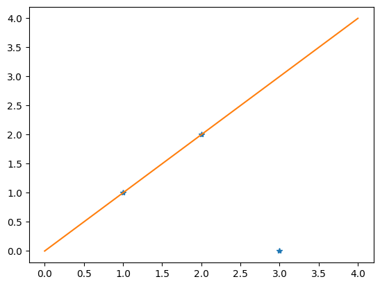

```python
#2)
import matplotlib.pyplot as plt

matriz4 = np.array([1,1,1,4,2,1,0,0,1]).reshape((3,3))
b4 = np.array([1,2,0])
sol4 = lng.solve(matriz4,b4)

a = int(sol4[0])
b = int(sol4[1])
c = int(sol4[2])

print("a =", a)
print("b =", b)
print("c =", c)
print(sol4)

# Definir los puntos xx y yy
xx = np.array([1, 2, 3])
yy = np.array([1, 2, 0])
x = np.linspace(0, 4, 100)
f = lambda t: a * t**2 + b * t + c
# Graficar los puntos xx y yy
plt.plot(xx, yy, '*')
# Graficar la función f
plt.plot(x, f(x))
plt.show()
```

```python
from ast import For
from typing import Iterator
#3)

def traza(A):
    resp = 0
    for i in range(len(A)):
        for j in range(len(A[i])):  # Iterar sobre los índices de la matriz
            if i == j:
                resp += A[i][j]  # Sumar los elementos de la diagonal principal
    return resp

def sumamodulo(A):
    resp = np.inf
    ##  CODIGO A COMPLETAR
    resp = np.abs(A[:,:]).sum()
    ##
    return resp


def positivosmayoresanegativos(A):
    resp = True
    ##  CODIGO A COMPLETAR
    sumaposi = 0
    sumanega = 0

    for i in range(len(A)):
        for j in range(len(A[i])):
            if (A[i][j]< 0):
                sumanega = abs( A[i][j]) + sumanega
            else:
                sumaposi = A[i][j] + sumaposi

    resp = sumaposi  > sumanega
    return resp

def main():

    #Definición de matriz
    A = np.array([[ 1, -2, -1, -2],
                  [-4, -4,  5, -9],
                  [-9,  0,  8, -1],
                  [ 8,  3,  3, -3]])

    print('Matriz A\n', A)

    print('Traza de A:', traza(A))
    assert traza(A)==2

    print('Suma en módulo de elementos de A:', sumamodulo(A))
    assert sumamodulo(A)==63

    print('Positivos mayores a negativos?:', positivosmayoresanegativos(A))
    assert positivosmayoresanegativos(A)==False


if __name__ == "__main__":
    main()
```

```
Matriz A
 [[ 1 -2 -1 -2]
 [-4 -4  5 -9]
 [-9  0  8 -1]
 [ 8  3  3 -3]]
Traza de A: 2
Suma en módulo de elementos de A: 63
Positivos mayores a negativos?: False
```

```python
#Para recordar
a = [1, 2, 3, 4, 5]

# Usando range(len(a))
for i in range(len(a)):
    print(a[i])  # Accediendo a los elementos de a usando los índices proporcionados por range(len(a))

# Sin usar range(len(a))
for elemento in a:
    print(elemento)  # Accediendo directamente a los elementos de a
```

```
1
2
3
4
5
1
2
3
4
5
```